# PR’s Stats Report!

Following our [Stats Plan](https://docs.google.com/document/d/1_g8_V2ESLxH-AMdoj7yamoreHwXQvpMx8RRAJs7HnSA/edit#)…

# Loading Files

Here’s our dataset.

```r
library(tidyverse)
library(janitor)
library(lubridate)
library(skimr)
library(lme4)
library(jtools)
library(Hmisc)
# Question Data
question_key <- read_csv("InferentialStatusKey copy.csv") %>%
  clean_names() %>%
  mutate(question_number = tolower(question_number),
         literal_status = tolower(literal_status)) %>%
  separate(question_number, into = c("left","right")) %>%
  unite(col = "question_number", left, right, sep = "_") %>%
  select(question_number, literal_status) # drop all other columns for now
# Full Data
fulldata <- read_csv("CMP4_FullData_9.25.18.csv") %>%
  clean_names() %>%
  select(-(answer1:answer15)) %>% # remove answers
  filter(age_at_test <= 18) %>% # 18 or below
  filter(age_at_test > 7) %>% # 8 or older
  filter(school != "HSDB") %>% # No HSDB
  mutate(assessment_date = dmy(assessment_date)) %>%
  group_by(student_id) %>%
  arrange(assessment_date) %>%
  slice(1) %>% # Keep earliest assessment date, throw away all later assessments
  ungroup() %>%
  mutate_at(vars(parents, ethnicity, student_id, school), as.factor)
# Calculate IC and LC scores
ic_lc_scores_cleaned <- fulldata %>%
  select(student_id, answ_rw1:answ_rw15) %>%
  select(-c(answ_rw6, answ_rw7, answ_rw10)) %>%
  gather(key = "question_number", value = "answer", answ_rw1:answ_rw15)
ic_lc_scores <- ic_lc_scores_cleaned %>%
  left_join(question_key, by = "question_number") %>%
  group_by(student_id, literal_status) %>%
  summarise(mean = mean(answer, na.rm = T)) %>%
  spread(literal_status, mean)
task_percents <- ic_lc_scores_cleaned %>%
  group_by(student_id) %>%
  summarise(task_percent = mean(answer, na.rm = T))
# Add IC and LC scores back into fulldata
fulldata <- fulldata %>%
  select(-task_percent) %>%
  left_join(ic_lc_scores, by = "student_id") %>%
  left_join(task_percents, by = "student_id")
fulldata
```

| student_id | school | assessment_date | age_at_test | age_of_entry | parents | student_rating | ethnicity | answ_rw1 | answ_rw2 | answ_rw3 | answ_rw4 | answ_rw5 | answ_rw6 | answ_rw7 | answ_rw8 | answ_rw9 | answ_rw10 | answ_rw11 | answ_rw12 | answ_rw13 | answ_rw14 | answ_rw15 | ang3 | ant4 | ritls | ropl | ropla | roplab | roplb | … |
| --- | --- | --- | --- | --- | --- | --- | --- | --- | --- | --- | --- | --- | --- | --- | --- | --- | --- | --- | --- | --- | --- | --- | --- | --- | --- | --- | --- | --- | --- | --- |
| 686 | TLC | 2015-11-02 | 15 | NA | DP | 3 | White - not Hispanic or Latino | 1 | 1 | 1 | 1 | 1 | 1 | 1 | 1 | 1 | 0 | 1 | 1 | 1 | 1 | 1 | 0.91666667 | 1.00000000 | 0.00 | NA | 0.82608696 | 0.7555556 | 0.68181818 | … |
| 687 | TLC | 2015-11-02 | 15 | NA | HP | 2 | White - not Hispanic or Latino | 1 | 1 | 1 | 1 | 1 | 1 | 1 | 1 | 1 | 1 | 1 | 1 | 1 | 1 | 1 | 0.95833333 | 1.00000000 | 0.00 | NA | 0.86956522 | 0.8444444 | 0.81818182 | … |
| 688 | TLC | 2015-11-02 | 16 | NA | DP | 4 | White - not Hispanic or Latino | 0 | 1 | 0 | 0 | 0 | 0 | 0 | 0 | 0 | 0 | 0 | 0 | 0 | 0 | 0 | 0.29166667 | 0.00000000 | 0.00 | NA | 0.26086957 | 0.2444444 | 0.22727273 | … |
| 690 | TLC | 2015-11-02 | 17 | NA | HP | 2 | Hispanic or Latino | 1 | 1 | 1 | 1 | 1 | 1 | 0 | 1 | 1 | 1 | 1 | 1 | 1 | 1 | 1 | 0.87500000 | 1.00000000 | 0.00 | NA | 0.86956522 | 0.8000000 | 0.72727273 | … |
| 691 | TLC | 2015-11-02 | 16 | NA | HP | 2 | White - not Hispanic or Latino | 1 | 1 | 1 | 1 | 1 | 1 | 1 | 1 | 1 | 1 | 1 | 1 | 1 | 1 | 1 | 0.95833333 | 1.00000000 | 0.00 | NA | 0.65217391 | 0.7333333 | 0.81818182 | … |
| 709 | TLC | 2015-11-02 | 18 | NA | HP | 3 | White - not Hispanic or Latino | 1 | 0 | 1 | 1 | 0 | 1 | 0 | 1 | 1 | 0 | 1 | 1 | 1 | 1 | 1 | 0.87500000 | NA | 0.00 | NA | 0.78260870 | 0.7333333 | 0.68181818 | … |
| 719 | TLC | 2015-11-02 | 17 | NA | DP | 3 | White - not Hispanic or Latino | 1 | 1 | 1 | 1 | 0 | 0 | 0 | 1 | 1 | 1 | 0 | 1 | 0 | 1 | 0 | 0.75000000 | 0.92857143 | 0.00 | NA | 0.78260870 | 0.8000000 | 0.81818182 | … |
| 731 | TLC | 2015-11-02 | 15 | NA | HP | 3 | Hispanic or Latino | 0 | 0 | 0 | 0 | 0 | 0 | 0 | 0 | 0 | 0 | 1 | 0 | 1 | 0 | 1 | 0.12500000 | 0.92857143 | 0.00 | NA | 0.78260870 | 0.7555556 | 0.72727273 | … |
| 735 | TLC | 2015-11-02 | 17 | NA | DP | 4 | White - not Hispanic or Latino | 1 | 1 | 0 | 0 | 0 | 0 | 0 | 1 | 1 | 1 | 1 | 1 | 0 | 1 | 0 | 0.70833333 | 0.50000000 | 0.00 | NA | 0.82608696 | 0.8000000 | 0.77272727 | … |
| 736 | TLC | 2015-11-02 | 15 | NA | DP | 3 | White - not Hispanic or Latino | 1 | 1 | 0 | 1 | 1 | 0 | 1 | 1 | 1 | 1 | 1 | 1 | 1 | 1 | 1 | 0.91666667 | 1.00000000 | 0.00 | NA | 0.86956522 | 0.8222222 | 0.77272727 | … |

[output cut: 293 more lines]

# Checking for Vocabulary Correlations

Let’s check if `ant4` and `syn4` are correlated or not. If they’re correlated, we want to group them in a new composite. If they’re not, treat them as separate predictors.

```r
vocab_corr <- cor.test(fulldata$ant4, fulldata$syn4, use = "complete.obs")
```

So `ant4` and `syn4` are very correlated, with r = 0.76688 and p = 0. So we’ll make a new composite `vocab` by averaging together `ant4` and `syn4`. If one of the test scores is missing from a student’s data, we’ll use the other one in its place. Here’s some examples of our new `vocab` composite score.

```r
# Calculate composites
composites <- fulldata %>%
  select(student_id, syn4, ant4) %>%
  group_by(student_id) %>%
  gather(key = "test", value = "score", syn4, ant4) %>%
  group_by(student_id) %>%
  summarise(vocab = mean(score, na.rm = T))
# Join back to fulldata
fulldata <- fulldata %>%
  left_join(composites, by = "student_id")
# See composites
fulldata %>%
  select(student_id, syn4, ant4, vocab) %>%
  head(20)
```

| student_id | syn4 | ant4 | vocab |
| --- | --- | --- | --- |
| 686 | 0.92857143 | 1.0000000 | 0.9642857 |
| 687 | 0.78571429 | 1.0000000 | 0.8928571 |
| 688 | 0.35714286 | 0.0000000 | 0.1785714 |
| 690 | 0.85714286 | 1.0000000 | 0.9285714 |
| 691 | 0.92857143 | 1.0000000 | 0.9642857 |
| 709 | 0.92857143 | NA | 0.9285714 |
| 719 | 0.57142857 | 0.9285714 | 0.7500000 |
| 731 | 0.78571429 | 0.9285714 | 0.8571429 |
| 735 | 0.42857143 | 0.5000000 | 0.4642857 |
| 736 | 0.85714286 | 1.0000000 | 0.9285714 |

[output cut: 10 more lines]

# Descriptive Stats

We’ll show DP and HP separately, and then both together.

## Deaf Parents

```r
describe <- fulldata %>%
  select(student_id,
         school,
         age_at_test,
         parents,
         student_rating,
         ethnicity,
         ant4,
         syn4,
         vocab,
         vocda2,
         stxd4,
         literal,
         inferential,
         task_percent)
data_dp <- describe %>% filter(parents == "DP")
data_hp <- describe %>% filter(parents == "HP")
skim(data_dp)
```

```
Skim summary statistics
 n obs: 105
 n variables: 14

── Variable type:factor ────────────────────────────────────────────────────────────────────────
   variable missing complete   n n_unique                        top_counts ordered
  ethnicity      11       94 105        8  Whi: 40, Whi: 35, NA: 11, His: 5   FALSE
    parents       0      105 105        1             DP: 105, HP: 0, NA: 0   FALSE
     school       0      105 105        4 TLC: 57, ISD: 31, RSD: 16, RIS: 1   FALSE
 student_id       0      105 105      105    686: 1, 688: 1, 719: 1, 735: 1   FALSE

── Variable type:numeric ───────────────────────────────────────────────────────────────────────
       variable missing complete   n  mean   sd    p0  p25   p50   p75  p100     hist
    age_at_test       0      105 105 11.15 2.76 8     9    10    13    18    ▇▅▃▃▂▁▁▂
           ant4      17       88 105  0.69 0.32 0     0.41  0.86  0.93  1    ▁▂▂▁▁▁▃▇
    inferential       0      105 105  0.65 0.32 0     0.4   0.8   0.8   1    ▂▂▁▂▅▁▇▆
        literal       0      105 105  0.7  0.28 0     0.43  0.71  1     1    ▁▂▂▂▃▃▆▇
 student_rating      19       86 105  1.83 0.92 1     1     2     2.75  4    ▇▁▅▁▁▃▁▁
          stxd4       1      104 105  0.52 0.23 0     0.37  0.52  0.7   0.96 ▂▂▃▇▅▆▅▃
           syn4      17       88 105  0.64 0.24 0.071 0.43  0.68  0.86  1    ▁▂▅▆▆▃▇▇
   task_percent       0      105 105  0.68 0.28 0.083 0.42  0.75  0.92  1    ▁▃▂▁▂▅▃▇
          vocab      16       89 105  0.66 0.26 0.14  0.43  0.75  0.89  1    ▂▅▃▂▁▇▅▇
         vocda2       2      103 105  0.6  0.22 0.04  0.42  0.64  0.76  1    ▁▂▅▆▇▇▆▂
```

## Hearing Parents

```r
skim(data_hp)
```

```
Skim summary statistics
 n obs: 198
 n variables: 14

── Variable type:factor ────────────────────────────────────────────────────────────────────────
   variable missing complete   n n_unique                         top_counts ordered
  ethnicity      10      188 198       12 Whi: 51, Whi: 44, His: 22, His: 16   FALSE
    parents       0      198 198        1              HP: 198, DP: 0, NA: 0   FALSE
     school       0      198 198        4 TLC: 93, RSD: 40, RIS: 39, ISD: 26   FALSE
 student_id       0      198 198      198     687: 1, 690: 1, 691: 1, 709: 1   FALSE

── Variable type:numeric ───────────────────────────────────────────────────────────────────────
       variable missing complete   n  mean   sd    p0   p25   p50   p75  p100     hist
    age_at_test       0      198 198 12.28 3.07 8     10    11    15    18    ▇▃▆▅▂▃▃▃
           ant4      42      156 198  0.52 0.31 0.071  0.27  0.43  0.79  1    ▅▇▃▃▂▂▅▆
    inferential       0      198 198  0.53 0.33 0      0.2   0.45  0.8   1    ▃▆▁▇▅▁▇▆
        literal       0      198 198  0.54 0.33 0      0.29  0.57  0.86  1    ▃▅▇▆▅▃▆▇
 student_rating      25      173 198  2.6  1.02 1      2     3     3     4    ▃▁▇▁▁▇▁▆
          stxd4       1      197 198  0.44 0.22 0.037  0.26  0.37  0.63  0.96 ▂▇▇▂▅▃▃▂
           syn4      43      155 198  0.45 0.28 0      0.21  0.43  0.68  1    ▅▇▆▆▁▆▆▃
   task_percent       0      198 198  0.54 0.3  0      0.25  0.5   0.83  1    ▂▇▅▅▂▃▃▇
          vocab      41      157 198  0.48 0.28 0.071  0.21  0.43  0.75  1    ▇▇▅▃▅▃▅▅
         vocda2       1      197 198  0.44 0.24 0.04   0.24  0.4   0.64  1    ▃▇▇▇▂▃▅▁
```

## All Children

```r
skim(describe)
```

```
Skim summary statistics
 n obs: 303
 n variables: 14

── Variable type:factor ────────────────────────────────────────────────────────────────────────
   variable missing complete   n n_unique                          top_counts ordered
  ethnicity      21      282 303       12  Whi: 86, Whi: 84, His: 27, His: 21   FALSE
    parents       0      303 303        2             HP: 198, DP: 105, NA: 0   FALSE
     school       0      303 303        4 TLC: 150, ISD: 57, RSD: 56, RIS: 40   FALSE
 student_id       0      303 303      303      686: 1, 687: 1, 688: 1, 690: 1   FALSE

── Variable type:numeric ───────────────────────────────────────────────────────────────────────
       variable missing complete   n  mean   sd    p0  p25   p50   p75  p100     hist
    age_at_test       0      303 303 11.89 3.01 8     9    11    14    18    ▇▅▅▃▂▂▂▃
           ant4      59      244 303  0.58 0.32 0     0.29  0.57  0.93  1    ▂▅▅▂▁▂▅▇
    inferential       0      303 303  0.57 0.33 0     0.2   0.6   0.8   1    ▃▅▁▆▅▁▇▇
        literal       0      303 303  0.6  0.32 0     0.29  0.57  0.86  1    ▂▃▅▅▃▃▆▇
 student_rating      44      259 303  2.34 1.05 1     1     2     3     4    ▇▁▇▁▁▇▁▅
          stxd4       2      301 303  0.47 0.23 0     0.26  0.44  0.67  0.96 ▂▅▇▆▅▅▅▂
           syn4      60      243 303  0.52 0.28 0     0.29  0.5   0.79  1    ▅▇▇▇▃▇▇▆
   task_percent       0      303 303  0.59 0.3  0     0.33  0.58  0.83  1    ▁▆▃▃▂▅▃▇
          vocab      57      246 303  0.55 0.28 0.071 0.25  0.5   0.82  1    ▆▇▆▅▃▅▆▇
         vocda2       3      300 303  0.5  0.25 0.04  0.28  0.44  0.72  1    ▃▆▇▇▅▆▆▂
```

# Correlation Tables

Now we’ll do correlation tables - DP, HP, and All. The first table shows r values, the second table shows p-values.

## Deaf Parents

```r
correlate <- fulldata %>%
  select(age_at_test,
         parents,
         vocab,
         vocda2,
         stxd4,
         literal,
         inferential,
         task_percent)
correlate_dp <- correlate %>%
  filter(parents == "DP") %>%
  select(-parents) %>%
  as.matrix()
correlate_hp <- correlate %>%
  filter(parents == "HP") %>%
  select(-parents) %>%
  as.matrix()
correlate <- correlate %>%
  select(-parents) %>%
  as.matrix()
rcorr(correlate_dp)$r %>% round(., 2)
```

```
             age_at_test vocab vocda2 stxd4 literal inferential task_percent
age_at_test         1.00  0.04   0.20  0.11    0.07        0.09         0.08
vocab               0.04  1.00   0.82  0.77    0.75        0.63         0.76
vocda2              0.20  0.82   1.00  0.82    0.71        0.64         0.73
stxd4               0.11  0.77   0.82  1.00    0.62        0.60         0.66
literal             0.07  0.75   0.71  0.62    1.00        0.70         0.94
inferential         0.09  0.63   0.64  0.60    0.70        1.00         0.90
task_percent        0.08  0.76   0.73  0.66    0.94        0.90         1.00
```

```r
rcorr(correlate_dp)$P %>% round(., 4)
```

```
             age_at_test  vocab vocda2  stxd4 literal inferential task_percent
age_at_test           NA 0.7132 0.0399 0.2588  0.5086      0.3673       0.4071
vocab             0.7132     NA 0.0000 0.0000  0.0000      0.0000       0.0000
vocda2            0.0399 0.0000     NA 0.0000  0.0000      0.0000       0.0000
stxd4             0.2588 0.0000 0.0000     NA  0.0000      0.0000       0.0000
literal           0.5086 0.0000 0.0000 0.0000      NA      0.0000       0.0000
inferential       0.3673 0.0000 0.0000 0.0000  0.0000          NA       0.0000
task_percent      0.4071 0.0000 0.0000 0.0000  0.0000      0.0000           NA
```

## Hearing Parents

```r
rcorr(correlate_hp)$r %>% round(., 2)
```

```
             age_at_test vocab vocda2 stxd4 literal inferential task_percent
age_at_test         1.00  0.34   0.47  0.38    0.26        0.29         0.29
vocab               0.34  1.00   0.79  0.79    0.74        0.72         0.79
vocda2              0.47  0.79   1.00  0.74    0.69        0.68         0.74
stxd4               0.38  0.79   0.74  1.00    0.72        0.69         0.76
literal             0.26  0.74   0.69  0.72    1.00        0.70         0.95
inferential         0.29  0.72   0.68  0.69    0.70        1.00         0.89
task_percent        0.29  0.79   0.74  0.76    0.95        0.89         1.00
```

```r
rcorr(correlate_hp)$P %>% round(., 4)
```

```
             age_at_test vocab vocda2 stxd4 literal inferential task_percent
age_at_test           NA     0      0     0   2e-04           0            0
vocab              0e+00    NA      0     0   0e+00           0            0
vocda2             0e+00     0     NA     0   0e+00           0            0
stxd4              0e+00     0      0    NA   0e+00           0            0
literal            2e-04     0      0     0      NA           0            0
inferential        0e+00     0      0     0   0e+00          NA            0
task_percent       0e+00     0      0     0   0e+00           0           NA
```

## All Children

```r
rcorr(correlate)$r %>% round(., 2)
```

```
             age_at_test vocab vocda2 stxd4 literal inferential task_percent
age_at_test         1.00  0.18   0.31  0.26    0.15        0.19         0.18
vocab               0.18  1.00   0.82  0.79    0.77        0.70         0.80
vocda2              0.31  0.82   1.00  0.77    0.71        0.68         0.75
stxd4               0.26  0.79   0.77  1.00    0.70        0.67         0.74
literal             0.15  0.77   0.71  0.70    1.00        0.71         0.95
inferential         0.19  0.70   0.68  0.67    0.71        1.00         0.90
task_percent        0.18  0.80   0.75  0.74    0.95        0.90         1.00
```

```r
rcorr(correlate)$P %>% round(., 4)
```

```
             age_at_test  vocab vocda2 stxd4 literal inferential task_percent
age_at_test           NA 0.0053      0     0  0.0082      0.0011       0.0018
vocab             0.0053     NA      0     0  0.0000      0.0000       0.0000
vocda2            0.0000 0.0000     NA     0  0.0000      0.0000       0.0000
stxd4             0.0000 0.0000      0    NA  0.0000      0.0000       0.0000
literal           0.0082 0.0000      0     0      NA      0.0000       0.0000
inferential       0.0011 0.0000      0     0  0.0000          NA       0.0000
task_percent      0.0018 0.0000      0     0  0.0000      0.0000           NA
```

# HiReAn: Literal ASL

Before we start the hierarchical regressions, I’m going to reduce the dataset to only the variables we’re looking at, and then drop any rows that are missing any of the variables we are using here. Doing so, 60 rows were dropped. Let’s see those we dropped, below. Almost of them were dropped because they didn’t take the `ant4` and `syn4` tests, that’s why.

```r
testdata <- fulldata %>%
  select(age_at_test, parents, vocab, vocda2, stxd4, literal, inferential, task_percent) %>%
  drop_na
anti_join(fulldata, testdata) %>%
  select(age_at_test, parents, ant4, syn4, vocab, vocda2, stxd4, literal, inferential, task_percent)
```

| age_at_test | parents | ant4 | syn4 | vocab | vocda2 | stxd4 | literal | inferential | task_percent |
| --- | --- | --- | --- | --- | --- | --- | --- | --- | --- |
| 12 | DP | 0.2142857 | NA | 0.2142857 | NA | 0.14814815 | 0.1428571 | 0.2 | 0.16666667 |
| 11 | HP | NA | NA | NaN | 0.16 | 0.25925926 | 0.2857143 | 0.2 | 0.25000000 |
| 8 | HP | 0.8571429 | 0.7142857 | 0.7857143 | NA | NA | 0.2857143 | 0.6 | 0.41666667 |
| 8 | DP | 0.9285714 | 0.5714286 | 0.7500000 | NA | NA | 0.8571429 | 1.0 | 0.91666667 |
| 12 | DP | NA | NA | NaN | 0.52 | 0.59259259 | 0.4285714 | 0.2 | 0.33333333 |
| 11 | DP | NA | NA | NaN | 0.72 | 0.74074074 | 1.0000000 | 0.8 | 0.91666667 |
| 15 | HP | NA | NA | NaN | 0.36 | 0.18518519 | 0.1428571 | 0.0 | 0.08333333 |
| 9 | HP | NA | NA | NaN | 0.64 | 0.37037037 | 0.8571429 | 0.6 | 0.75000000 |
| 8 | HP | NA | NA | NaN | 0.20 | 0.29629630 | 0.4285714 | 0.0 | 0.25000000 |
| 10 | HP | NA | NA | NaN | 0.44 | 0.18518519 | 0.2857143 | 0.0 | 0.16666667 |

[output cut: 50 more lines]

Now the models, with outcome being Literal ASL.

```r
lc_fit1 <- lm(data = testdata, literal ~ age_at_test)
lc_fit2 <- lm(data = testdata, literal ~ age_at_test + parents)
lc_fit3 <- lm(data = testdata, literal ~ age_at_test + parents + vocab + vocda2)
lc_fit4 <- lm(data = testdata, literal ~ age_at_test + parents + vocab + vocda2 + stxd4)
anova(lc_fit1, lc_fit2, lc_fit3, lc_fit4)
```

```
Analysis of Variance Table

Model 1: literal ~ age_at_test
Model 2: literal ~ age_at_test + parents
Model 3: literal ~ age_at_test + parents + vocab + vocda2
Model 4: literal ~ age_at_test + parents + vocab + vocda2 + stxd4
  Res.Df     RSS Df Sum of Sq        F    Pr(>F)
1    241 24.5445
2    240 22.6498  1    1.8947  49.5059 2.111e-11 ***
3    238  9.4112  2   13.2385 172.9547 < 2.2e-16 ***
4    237  9.0704  1    0.3409   8.9062  0.003139 **
---
Signif. codes:  0 ‘***’ 0.001 ‘**’ 0.01 ‘*’ 0.05 ‘.’ 0.1 ‘ ’ 1
```

```r
summ(lc_fit1)
```

```
MODEL INFO:
Observations: 243
Dependent Variable: literal
Type: OLS linear regression

MODEL FIT:
F(1,241) = 2.73, p = 0.10
R² = 0.01
Adj. R² = 0.01

Standard errors: OLS
```

|  | Est. | S.E. | t val. | p |  |
| --- | --- | --- | --- | --- | --- |
| (Intercept) | 0.46 | 0.08 | 5.67 | 0.00 | *** |
| age_at_test | 0.01 | 0.01 | 1.65 | 0.10 |  |

```r
summ(lc_fit2)
```

```
MODEL INFO:
Observations: 243
Dependent Variable: literal
Type: OLS linear regression

MODEL FIT:
F(2,240) = 11.51, p = 0.00
R² = 0.09
Adj. R² = 0.08

Standard errors: OLS
```

|  | Est. | S.E. | t val. | p |  |
| --- | --- | --- | --- | --- | --- |
| (Intercept) | 0.53 | 0.08 | 6.58 | 0.00 | *** |
| age_at_test | 0.02 | 0.01 | 2.44 | 0.02 | * |
| parentsHP | -0.19 | 0.04 | -4.48 | 0.00 | *** |

```r
summ(lc_fit3)
```

```
MODEL INFO:
Observations: 243
Dependent Variable: literal
Type: OLS linear regression

MODEL FIT:
F(4,238) = 97.43, p = 0.00
R² = 0.62
Adj. R² = 0.61

Standard errors: OLS
```

|  | Est. | S.E. | t val. | p |  |
| --- | --- | --- | --- | --- | --- |
| (Intercept) | 0.15 | 0.06 | 2.79 | 0.01 | ** |
| age_at_test | -0.01 | 0.00 | -1.93 | 0.06 | . |
| parentsHP | 0.02 | 0.03 | 0.78 | 0.44 |  |
| vocab | 0.61 | 0.08 | 7.73 | 0.00 | *** |
| vocda2 | 0.40 | 0.10 | 4.16 | 0.00 | *** |

```r
summ(lc_fit4)
```

```
MODEL INFO:
Observations: 243
Dependent Variable: literal
Type: OLS linear regression

MODEL FIT:
F(5,237) = 82.31, p = 0.00
R² = 0.63
Adj. R² = 0.63

Standard errors: OLS
```

|  | Est. | S.E. | t val. | p |  |
| --- | --- | --- | --- | --- | --- |
| (Intercept) | 0.15 | 0.05 | 2.69 | 0.01 | ** |
| age_at_test | -0.01 | 0.00 | -2.00 | 0.05 | * |
| parentsHP | 0.01 | 0.03 | 0.29 | 0.77 |  |
| vocab | 0.50 | 0.09 | 5.73 | 0.00 | *** |
| vocda2 | 0.30 | 0.10 | 2.97 | 0.00 | ** |
| stxd4 | 0.29 | 0.10 | 2.98 | 0.00 | ** |

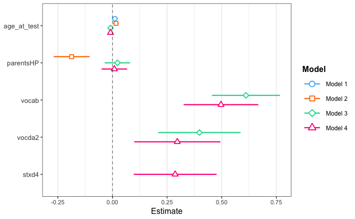

```r
plot_summs(lc_fit1, lc_fit2, lc_fit3, lc_fit4)
```

# HiReAn: Inferential ASL

Now the models for Inferential ASL.

```r
ic_fit1 <- lm(data = testdata, inferential ~ age_at_test)
ic_fit2 <- lm(data = testdata, inferential ~ age_at_test + parents)
ic_fit3 <- lm(data = testdata, inferential ~ age_at_test + parents + vocab + vocda2)
ic_fit4 <- lm(data = testdata, inferential ~ age_at_test + parents + vocab + vocda2 + stxd4)
anova(ic_fit1, ic_fit2, ic_fit3, ic_fit4)
```

```
Analysis of Variance Table

Model 1: inferential ~ age_at_test
Model 2: inferential ~ age_at_test + parents
Model 3: inferential ~ age_at_test + parents + vocab + vocda2
Model 4: inferential ~ age_at_test + parents + vocab + vocda2 + stxd4
  Res.Df    RSS Df Sum of Sq       F    Pr(>F)
1    241 25.580
2    240 24.121  1    1.4596  29.448 1.417e-07 ***
3    238 12.427  2   11.6932 117.960 < 2.2e-16 ***
4    237 11.747  1    0.6807  13.734 0.0002622 ***
---
Signif. codes:  0 ‘***’ 0.001 ‘**’ 0.01 ‘*’ 0.05 ‘.’ 0.1 ‘ ’ 1
```

```r
summ(ic_fit1)
```

```
MODEL INFO:
Observations: 243
Dependent Variable: inferential
Type: OLS linear regression

MODEL FIT:
F(1,241) = 7.35, p = 0.01
R² = 0.03
Adj. R² = 0.03

Standard errors: OLS
```

|  | Est. | S.E. | t val. | p |  |
| --- | --- | --- | --- | --- | --- |
| (Intercept) | 0.35 | 0.08 | 4.17 | 0.00 | *** |
| age_at_test | 0.02 | 0.01 | 2.71 | 0.01 | ** |

```r
summ(ic_fit2)
```

```
MODEL INFO:
Observations: 243
Dependent Variable: inferential
Type: OLS linear regression

MODEL FIT:
F(2,240) = 11.14, p = 0.00
R² = 0.08
Adj. R² = 0.08

Standard errors: OLS
```

|  | Est. | S.E. | t val. | p |  |
| --- | --- | --- | --- | --- | --- |
| (Intercept) | 0.40 | 0.08 | 4.89 | 0.00 | *** |
| age_at_test | 0.02 | 0.01 | 3.38 | 0.00 | *** |
| parentsHP | -0.16 | 0.04 | -3.81 | 0.00 | *** |

```r
summ(ic_fit3)
```

```
MODEL INFO:
Observations: 243
Dependent Variable: inferential
Type: OLS linear regression

MODEL FIT:
F(4,238) = 66.71, p = 0.00
R² = 0.53
Adj. R² = 0.52

Standard errors: OLS
```

|  | Est. | S.E. | t val. | p |  |
| --- | --- | --- | --- | --- | --- |
| (Intercept) | 0.06 | 0.06 | 0.88 | 0.38 |  |
| age_at_test | -0.00 | 0.01 | -0.20 | 0.84 |  |
| parentsHP | 0.04 | 0.03 | 1.07 | 0.29 |  |
| vocab | 0.51 | 0.09 | 5.65 | 0.00 | *** |
| vocda2 | 0.45 | 0.11 | 4.11 | 0.00 | *** |

```r
summ(ic_fit4)
```

```
MODEL INFO:
Observations: 243
Dependent Variable: inferential
Type: OLS linear regression

MODEL FIT:
F(5,237) = 58.97, p = 0.00
R² = 0.55
Adj. R² = 0.54

Standard errors: OLS
```

|  | Est. | S.E. | t val. | p |  |
| --- | --- | --- | --- | --- | --- |
| (Intercept) | 0.05 | 0.06 | 0.72 | 0.47 |  |
| age_at_test | -0.00 | 0.01 | -0.26 | 0.79 |  |
| parentsHP | 0.02 | 0.03 | 0.48 | 0.63 |  |
| vocab | 0.35 | 0.10 | 3.57 | 0.00 | *** |
| vocda2 | 0.31 | 0.11 | 2.71 | 0.01 | ** |
| stxd4 | 0.41 | 0.11 | 3.71 | 0.00 | *** |

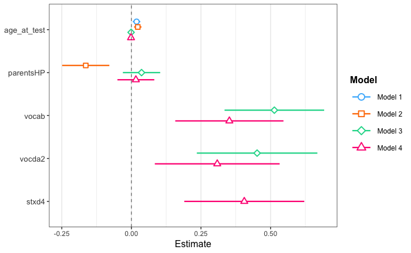

```r
plot_summs(ic_fit1, ic_fit2, ic_fit3, ic_fit4)
```

# HiReAn: Task Performance (ASL Comprehension)

Now the models for task performance.

```r
asl_fit1 <- lm(data = testdata, task_percent ~ age_at_test)
asl_fit2 <- lm(data = testdata, task_percent ~ age_at_test + parents)
asl_fit3 <- lm(data = testdata, task_percent ~ age_at_test + parents + vocab + vocda2)
asl_fit4 <- lm(data = testdata, task_percent ~ age_at_test + parents + vocab + vocda2 + stxd4)
anova(asl_fit1, asl_fit2, asl_fit3, asl_fit4)
```

```
Analysis of Variance Table

Model 1: task_percent ~ age_at_test
Model 2: task_percent ~ age_at_test + parents
Model 3: task_percent ~ age_at_test + parents + vocab + vocda2
Model 4: task_percent ~ age_at_test + parents + vocab + vocda2 + stxd4
  Res.Df     RSS Df Sum of Sq       F    Pr(>F)
1    241 21.4404
2    240 19.7322  1    1.7082  60.551 2.207e-13 ***
3    238  7.1511  2   12.5811 222.978 < 2.2e-16 ***
4    237  6.6861  1    0.4649  16.481 6.680e-05 ***
---
Signif. codes:  0 ‘***’ 0.001 ‘**’ 0.01 ‘*’ 0.05 ‘.’ 0.1 ‘ ’ 1
```

```r
summ(asl_fit1)
```

```
MODEL INFO:
Observations: 243
Dependent Variable: task_percent
Type: OLS linear regression

MODEL FIT:
F(1,241) = 5.12, p = 0.02
R² = 0.02
Adj. R² = 0.02

Standard errors: OLS
```

|  | Est. | S.E. | t val. | p |  |
| --- | --- | --- | --- | --- | --- |
| (Intercept) | 0.42 | 0.08 | 5.44 | 0.00 | *** |
| age_at_test | 0.01 | 0.01 | 2.26 | 0.02 | * |

```r
summ(asl_fit2)
```

```
MODEL INFO:
Observations: 243
Dependent Variable: task_percent
Type: OLS linear regression

MODEL FIT:
F(2,240) = 13.16, p = 0.00
R² = 0.10
Adj. R² = 0.09

Standard errors: OLS
```

|  | Est. | S.E. | t val. | p |  |
| --- | --- | --- | --- | --- | --- |
| (Intercept) | 0.47 | 0.07 | 6.37 | 0.00 | *** |
| age_at_test | 0.02 | 0.01 | 3.08 | 0.00 | ** |
| parentsHP | -0.18 | 0.04 | -4.56 | 0.00 | *** |

```r
summ(asl_fit3)
```

```
MODEL INFO:
Observations: 243
Dependent Variable: task_percent
Type: OLS linear regression

MODEL FIT:
F(4,238) = 122.68, p = 0.00
R² = 0.67
Adj. R² = 0.67

Standard errors: OLS
```

|  | Est. | S.E. | t val. | p |  |
| --- | --- | --- | --- | --- | --- |
| (Intercept) | 0.11 | 0.05 | 2.35 | 0.02 | * |
| age_at_test | -0.01 | 0.00 | -1.40 | 0.16 |  |
| parentsHP | 0.03 | 0.03 | 1.11 | 0.27 |  |
| vocab | 0.57 | 0.07 | 8.28 | 0.00 | *** |
| vocda2 | 0.42 | 0.08 | 5.04 | 0.00 | *** |

```r
summ(asl_fit4)
```

```
MODEL INFO:
Observations: 243
Dependent Variable: task_percent
Type: OLS linear regression

MODEL FIT:
F(5,237) = 107.83, p = 0.00
R² = 0.69
Adj. R² = 0.69

Standard errors: OLS
```

|  | Est. | S.E. | t val. | p |  |
| --- | --- | --- | --- | --- | --- |
| (Intercept) | 0.10 | 0.05 | 2.23 | 0.03 | * |
| age_at_test | -0.01 | 0.00 | -1.51 | 0.13 |  |
| parentsHP | 0.01 | 0.03 | 0.46 | 0.64 |  |
| vocab | 0.44 | 0.07 | 5.87 | 0.00 | *** |
| vocda2 | 0.30 | 0.09 | 3.51 | 0.00 | *** |
| stxd4 | 0.34 | 0.08 | 4.06 | 0.00 | *** |

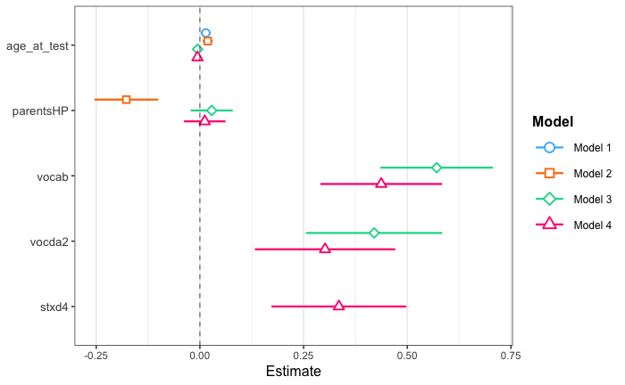

```r
plot_summs(asl_fit1, asl_fit2, asl_fit3, asl_fit4)
```

# Visualization

One big takeaway is that when the full model is computed, the DP/HP parent difference goes away. That is interesting, so let’s visualize that.

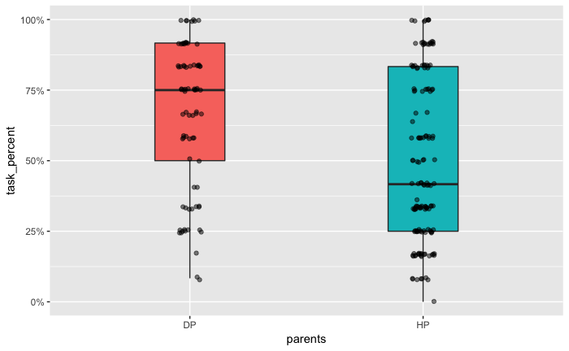

```r
testdata %>%
  ggplot(aes(x = parents, y = task_percent, fill = parents)) +
  geom_boxplot(width = 0.3) +
  geom_jitter(width = 0.05, alpha = 0.5) +
  scale_y_continuous(limits = c(0,1), labels = scales::percent) +
  guides(fill = F)
```

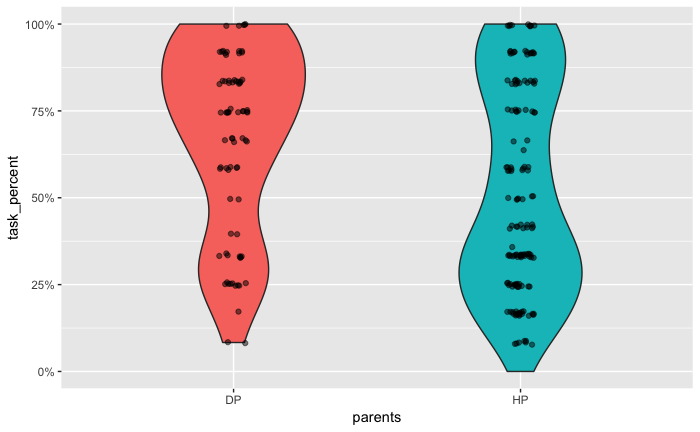

```r
testdata %>%
  ggplot(aes(x = parents, y = task_percent, fill = parents)) +
  geom_violin(width = 0.5) +
  geom_jitter(width = 0.05, alpha = 0.5) +
  scale_y_continuous(limits = c(0,1), labels = scales::percent) +
  guides(fill = F)
```

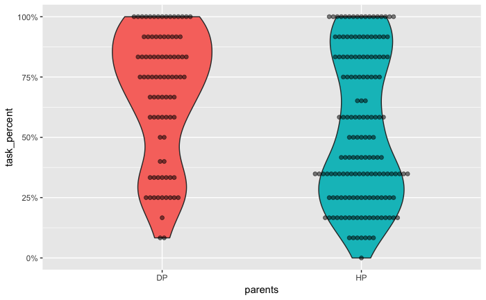

```r
testdata %>%
  ggplot(aes(x = parents, y = task_percent, fill = parents)) +
  geom_violin(width = 0.5) +
  geom_dotplot(binaxis='y', stackdir='center', dotsize=0.5, fill = "black", alpha = 0.5) +
  scale_y_continuous(limits = c(0,1), labels = scales::percent) +
  guides(fill = F)
```

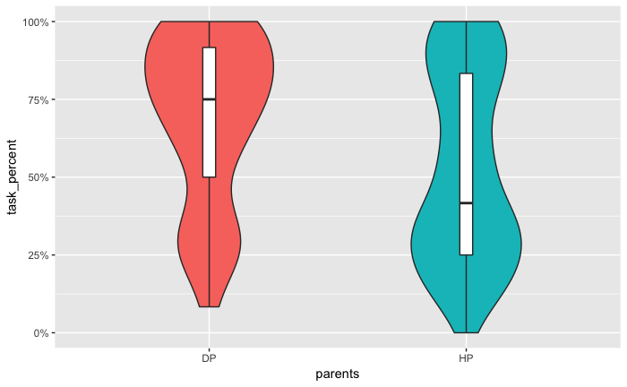

```r
testdata %>%
  ggplot(aes(x = parents, y = task_percent, fill = parents)) +
  geom_violin(width = 0.5) +
  geom_boxplot(width = 0.05, fill = "white") +
  scale_y_continuous(limits = c(0,1), labels = scales::percent) +
  guides(fill = F)
```

# TLC Testing

TLC took the test twice. Let’s compare their scores.

```r
tlcdata <- read_csv("CMP4_FullData_9.25.18.csv") %>%
  clean_names() %>%
  filter(school == "TLC") %>%
  mutate(time = case_when(
    assessment_date == '02/11/2015' ~ "time1",
    TRUE ~ "time2"
  )) %>%
  select(-(answer1:answer15)) %>% # remove answers
  filter(age_at_test <= 18) %>% # 18 or below
  filter(age_at_test > 7) %>% # 8 or older
  mutate_at(vars(parents, ethnicity, student_id, school), as.factor)
# Calculate IC and LC scores
ic_lc_scores_cleaned <- tlcdata %>%
  select(student_id, time, answ_rw1:answ_rw15) %>%
  select(-c(answ_rw6, answ_rw7, answ_rw10)) %>%
  gather(key = "question_number", value = "answer", answ_rw1:answ_rw15)
ic_lc_scores <- ic_lc_scores_cleaned %>%
  left_join(question_key, by = "question_number") %>%
  group_by(student_id, time, literal_status) %>%
  summarise(mean = mean(answer, na.rm = T)) %>%
  spread(literal_status, mean)
task_percents <- ic_lc_scores_cleaned %>%
  group_by(student_id, time) %>%
  summarise(task_percent = mean(answer, na.rm = T))
# Add IC and LC scores back into fulldata
tlcdata <- tlcdata %>%
  select(-task_percent) %>%
  left_join(ic_lc_scores, by = c("student_id", "time")) %>%
  left_join(task_percents, by = c("student_id", "time"))
tlcdata
```

| student_id | school | assessment_date | age_at_test | age_of_entry | parents | student_rating | ethnicity | answ_rw1 | answ_rw2 | answ_rw3 | answ_rw4 | answ_rw5 | answ_rw6 | answ_rw7 | answ_rw8 | answ_rw9 | answ_rw10 | answ_rw11 | answ_rw12 | answ_rw13 | answ_rw14 | answ_rw15 | ang3 | ant4 | ritls | ropl | ropla | roplab | roplb | … |
| --- | --- | --- | --- | --- | --- | --- | --- | --- | --- | --- | --- | --- | --- | --- | --- | --- | --- | --- | --- | --- | --- | --- | --- | --- | --- | --- | --- | --- | --- | --- |
| 1600 | TLC | 05/12/2016 | 15 | NA | DP | 2 | White - not Hispanic or Latino | 0 | 1 | 1 | 0 | 0 | 1 | 0 | 1 | 1 | 1 | 1 | 1 | 0 | 0 | 0 | 0.33333333 | 0.85714286 | 0.95 | NA | 0.52173913 | 0.64444444 | 0.7727273 | … |
| 1601 | TLC | 05/12/2016 | 14 | NA | HP | 1 | White - not Hispanic or Latino | 1 | 1 | 1 | 1 | 1 | 1 | 0 | 1 | 1 | 0 | 1 | 1 | 1 | 1 | 1 | 0.91666667 | 0.92857143 | 0.96 | NA | 0.73913043 | 0.73333333 | 0.7272727 | … |
| 1602 | TLC | 05/12/2016 | 13 | NA | DP | 1 | White - not Hispanic or Latino | 1 | 1 | 0 | 1 | 1 | 1 | 1 | 1 | 1 | 1 | 1 | 1 | 1 | 1 | 1 | 0.87500000 | 1.00000000 | 0.97 | NA | 0.78260870 | 0.84444444 | 0.9090909 | … |
| 1610 | TLC | 05/12/2016 | 15 | NA | HP | 4 | White - not Hispanic or Latino | 0 | 1 | 0 | 1 | 0 | 1 | 0 | 1 | 0 | 0 | 0 | 0 | 0 | 0 | 0 | 0.29166667 | 0.14285714 | 0.50 | NA | 0.26086957 | 0.26666667 | 0.2727273 | … |
| 1611 | TLC | 05/12/2016 | 15 | NA | HP | 3 | White - not Hispanic or Latino | 1 | 1 | 1 | 1 | 1 | 1 | 1 | 1 | 1 | 0 | 1 | 1 | 1 | 1 | 1 | 0.91666667 | 0.85714286 | 0.99 | NA | 0.78260870 | 0.75555556 | 0.7272727 | … |
| 1612 | TLC | 05/12/2016 | 18 | NA | HP | 2 | Hispanic or Latino | 1 | 1 | 1 | 1 | 1 | 1 | 0 | 1 | 1 | 0 | 1 | 1 | 1 | 1 | 1 | 0.83333333 | 1.00000000 | 0.97 | NA | 0.69565217 | 0.75555556 | 0.8181818 | … |
| 1613 | TLC | 05/12/2016 | 16 | NA | HP | 2 | White - not Hispanic or Latino | 1 | 1 | 1 | 1 | 1 | 1 | 1 | 1 | 1 | 1 | 1 | 1 | 1 | 1 | 1 | 0.87500000 | 1.00000000 | 0.97 | NA | 0.73913043 | 0.80000000 | 0.8636364 | … |
| 1614 | TLC | 05/12/2016 | 15 | NA | HP | 3 | Asian | 1 | 1 | 1 | 1 | 0 | 0 | 0 | 1 | 1 | 1 | 1 | 1 | 1 | 1 | 1 | 0.91666667 | 0.92857143 | 0.92 | NA | 0.82608696 | 0.84444444 | 0.8636364 | … |
| 1627 | TLC | 05/12/2016 | 13 | NA | DP | 2 | White - not Hispanic or Latino | 1 | 1 | 0 | 1 | 1 | 0 | 0 | 1 | 1 | 0 | 1 | 1 | 1 | 1 | 1 | 0.91666667 | 1.00000000 | 0.88 | NA | 0.73913043 | 0.73333333 | 0.7272727 | … |
| 1634 | TLC | 05/12/2016 | 18 | NA | HP | 3 | White - not Hispanic or Latino | 1 | 1 | 1 | 1 | 1 | 0 | 0 | 1 | 1 | 1 | 1 | 1 | 1 | 1 | 1 | 0.91666667 | 1.00000000 | 0.95 | NA | 0.86956522 | 0.82222222 | 0.7727273 | … |

[output cut: 236 more lines]

Correlation of task percent:

```r
tlcdata_task <- tlcdata %>%
  select(student_id, time, task_percent) %>%
  spread(time, task_percent)
cor.test(tlcdata_task$time1, tlcdata_task$time2, use = "complete.obs")
```

```
    Pearson's product-moment correlation

data:  tlcdata_task$time1 and tlcdata_task$time2
t = 11.444, df = 94, p-value < 2.2e-16
alternative hypothesis: true correlation is not equal to 0
95 percent confidence interval:
 0.6640822 0.8356443
sample estimates:
     cor
0.762985
```

Inferential score correlation:

```r
tlcdata_i <- tlcdata %>%
  select(student_id, time, inferential) %>%
  spread(time, inferential)
cor.test(tlcdata_i$time1, tlcdata_i$time2, use = "complete.obs")
```

```
    Pearson's product-moment correlation

data:  tlcdata_i$time1 and tlcdata_i$time2
t = 6.8051, df = 94, p-value = 9.336e-10
alternative hypothesis: true correlation is not equal to 0
95 percent confidence interval:
 0.4227001 0.6949428
sample estimates:
      cor
0.5744998
```

Literal score correlation:

```r
tlcdata_l <- tlcdata %>%
  select(student_id, time, literal) %>%
  spread(time, literal)
cor.test(tlcdata_l$time1, tlcdata_l$time2, use = "complete.obs")
```

```
    Pearson's product-moment correlation

data:  tlcdata_l$time1 and tlcdata_l$time2
t = 11.95, df = 94, p-value < 2.2e-16
alternative hypothesis: true correlation is not equal to 0
95 percent confidence interval:
 0.6823048 0.8454246
sample estimates:
      cor
0.7765628
```

# Starting Over, Sort Of.

## Descriptive data

> First, find the means/descriptive statistics for each variable based on three groups (All Deaf children, Deaf parents, and Hearing parents) that took the following tests: ASL-Text, SYN, ANT, VOCDA, and STXD4.

```r
completedata <- fulldata %>%
  select(student_id, age_at_test, parents, syn4, ant4, vocda2, stxd4, inferential, literal, task_percent) %>%
  drop_na()
```

So in this case, we’re going to only get complete cases from `fulldata` of all kids that have data points for all of them. That returns 239 cases.

Next are descriptive statistics for all kids and then deaf and hearing separately.

```r
skim(completedata)
```

[output not shown]

```r
completedata %>% group_by(parents) %>% skim
```

[output not shown]

## Correlations

> Then, a correlational analysis for each variable for all three groups (All Deaf children, Deaf parents, and hearing parents).

### All children

```r
library(corrr)
completedata %>%
  select_if(is.numeric) %>%
  correlate() %>%
  shave() %>%
  fashion()
```

```
Correlation method: 'pearson'
Missing treated using: 'pairwise.complete.obs'
```

| rowname | age_at_test | syn4 | ant4 | vocda2 | stxd4 | inferential | literal | task_percent |
| --- | --- | --- | --- | --- | --- | --- | --- | --- |
| age_at_test |  |  |  |  |  |  |  |  |
| syn4 | .19 |  |  |  |  |  |  |  |
| ant4 | .14 | .77 |  |  |  |  |  |  |
| vocda2 | .25 | .79 | .76 |  |  |  |  |  |
| stxd4 | .21 | .72 | .75 | .76 |  |  |  |  |
| inferential | .17 | .63 | .69 | .69 | .69 |  |  |  |
| literal | .09 | .70 | .74 | .71 | .70 | .72 |  |  |
| task_percent | .14 | .72 | .77 | .76 | .75 | .90 | .95 |  |

```
Correlation method: 'pearson'
Missing treated using: 'pairwise.complete.obs'
```

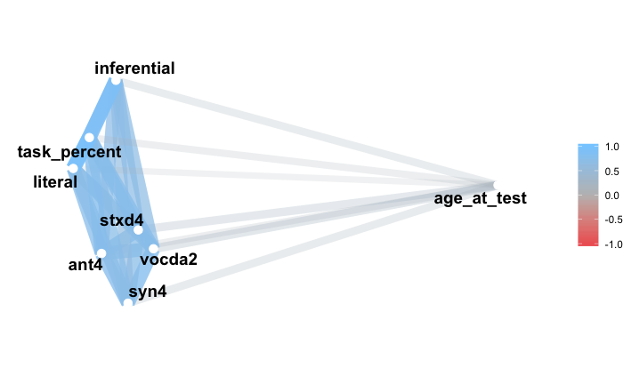

```r
completedata %>%
  select_if(is.numeric) %>%
  correlate() %>%
  network_plot(curved = F, min_cor = 0, colours = c("indianred2",
  "gray", "skyblue1"))
```

### DP children

```r
completedata %>%
  filter(parents == "DP") %>%
  select_if(is.numeric) %>%
  correlate() %>%
  shave() %>%
  fashion()
```

| rowname | age_at_test | syn4 | ant4 | vocda2 | stxd4 | inferential | literal | task_percent |
| --- | --- | --- | --- | --- | --- | --- | --- | --- |
| age_at_test |  |  |  |  |  |  |  |  |
| syn4 | .05 |  |  |  |  |  |  |  |
| ant4 | .05 | .72 |  |  |  |  |  |  |
| vocda2 | .11 | .77 | .76 |  |  |  |  |  |
| stxd4 | -.00 | .70 | .71 | .81 |  |  |  |  |
| inferential | .05 | .54 | .60 | .62 | .58 |  |  |  |
| literal | .02 | .67 | .71 | .69 | .60 | .68 |  |  |
| task_percent | .03 | .67 | .72 | .72 | .64 | .90 | .93 |  |

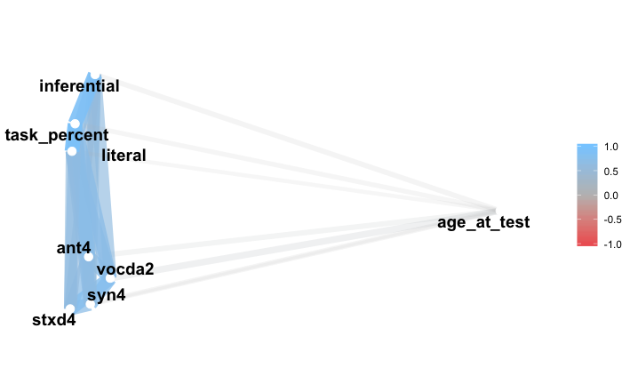

```r
completedata %>%
  filter(parents == "DP") %>%
  select_if(is.numeric) %>%
  correlate() %>%
  network_plot(curved = F, min_cor = 0, colours = c("indianred2",
  "gray", "skyblue1"))
```

### HP children

```r
completedata %>%
  filter(parents == "HP") %>%
  select_if(is.numeric) %>%
  correlate() %>%
  shave() %>%
  fashion()
```

| rowname | age_at_test | syn4 | ant4 | vocda2 | stxd4 | inferential | literal | task_percent |
| --- | --- | --- | --- | --- | --- | --- | --- | --- |
| age_at_test |  |  |  |  |  |  |  |  |
| syn4 | .36 |  |  |  |  |  |  |  |
| ant4 | .27 | .76 |  |  |  |  |  |  |
| vocda2 | .44 | .75 | .73 |  |  |  |  |  |
| stxd4 | .38 | .72 | .76 | .73 |  |  |  |  |
| inferential | .29 | .64 | .71 | .70 | .73 |  |  |  |
| literal | .20 | .68 | .73 | .69 | .73 | .72 |  |  |
| task_percent | .26 | .71 | .78 | .75 | .78 | .90 | .95 |  |

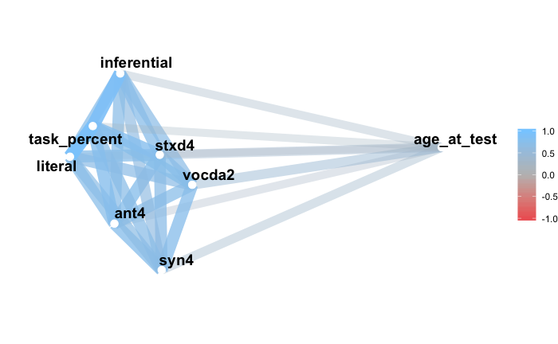

```r
completedata %>%
  filter(parents == "HP") %>%
  select_if(is.numeric) %>%
  correlate() %>%
  network_plot(curved = F, min_cor = 0, colours = c("indianred2",
  "gray", "skyblue1"))
```

## Linear Modeling

First, we generate full models with outcomes literal, inferential, and all.

```r
m_lc <- lm(data = completedata, literal ~ age_at_test * parents + stxd4 + vocab_composite)
m_ic <- lm(data = completedata, inferential ~ age_at_test * parents + stxd4 + vocab_composite)
m_all <- lm(data = completedata, task_percent ~ age_at_test * parents + stxd4 + vocab_composite)
summary(m_lc)
```

```
Call:
lm(formula = literal ~ age_at_test * parents + stxd4 + vocab_composite,
    data = completedata)

Residuals:
     Min       1Q   Median       3Q      Max
-0.60168 -0.10164  0.02413  0.11241  0.60529

Coefficients:
                       Estimate Std. Error t value Pr(>|t|)
(Intercept)            0.080151   0.090434   0.886  0.37637
age_at_test           -0.002972   0.007361  -0.404  0.68672
parentsHP              0.114194   0.109766   1.040  0.29926
stxd4                  0.299699   0.096221   3.115  0.00207 **
vocab_composite        0.778130   0.087984   8.844 2.33e-16 ***
age_at_test:parentsHP -0.008905   0.009124  -0.976  0.33004
---
Signif. codes:  0 ‘***’ 0.001 ‘**’ 0.01 ‘*’ 0.05 ‘.’ 0.1 ‘ ’ 1

Residual standard error: 0.1952 on 233 degrees of freedom
Multiple R-squared:  0.632, Adjusted R-squared:  0.6241
F-statistic: 80.02 on 5 and 233 DF,  p-value: < 2.2e-16
```

```r
summary(m_ic)
```

```
Call:
lm(formula = inferential ~ age_at_test * parents + stxd4 + vocab_composite,
    data = completedata)

Residuals:
     Min       1Q   Median       3Q      Max
-0.90592 -0.13422  0.01779  0.13380  0.80669

Coefficients:
                       Estimate Std. Error t value Pr(>|t|)
(Intercept)            0.014917   0.102976   0.145 0.884945
age_at_test            0.001552   0.008382   0.185 0.853239
parentsHP              0.033355   0.124990   0.267 0.789810
stxd4                  0.428898   0.109566   3.915 0.000119 ***
vocab_composite        0.626420   0.100187   6.253 1.91e-09 ***
age_at_test:parentsHP -0.001981   0.010389  -0.191 0.848974
---
Signif. codes:  0 ‘***’ 0.001 ‘**’ 0.01 ‘*’ 0.05 ‘.’ 0.1 ‘ ’ 1

Residual standard error: 0.2223 on 233 degrees of freedom
Multiple R-squared:  0.5582,    Adjusted R-squared:  0.5488
F-statistic: 58.89 on 5 and 233 DF,  p-value: < 2.2e-16
```

```r
summary(m_all)
```

```
Call:
lm(formula = task_percent ~ age_at_test * parents + stxd4 + vocab_composite,
    data = completedata)

Residuals:
     Min       1Q   Median       3Q      Max
-0.69510 -0.11022  0.01492  0.11205  0.52165

Coefficients:
                       Estimate Std. Error t value Pr(>|t|)
(Intercept)            0.053451   0.078267   0.683    0.495
age_at_test           -0.001127   0.006370  -0.177    0.860
parentsHP              0.079958   0.094998   0.842    0.401
stxd4                  0.352235   0.083275   4.230 3.36e-05 ***
vocab_composite        0.716033   0.076147   9.403  < 2e-16 ***
age_at_test:parentsHP -0.005972   0.007896  -0.756    0.450
---
Signif. codes:  0 ‘***’ 0.001 ‘**’ 0.01 ‘*’ 0.05 ‘.’ 0.1 ‘ ’ 1

Residual standard error: 0.1689 on 233 degrees of freedom
Multiple R-squared:  0.6912,    Adjusted R-squared:  0.6845
F-statistic: 104.3 on 5 and 233 DF,  p-value: < 2.2e-16
```

### Literal

Then for the literal model `m_lc` we remove either the vocab composite, or the syntax composite, and compare them against the full model.

```r
voc_m_lc <- lm(data = completedata, literal ~ age_at_test * parents + stxd4)
syntax_m_lc <- lm(data = completedata, literal ~ age_at_test * parents + vocab_composite)
summary(voc_m_lc)
```

```
Call:
lm(formula = literal ~ age_at_test * parents + stxd4, data = completedata)

Residuals:
     Min       1Q   Median       3Q      Max
-0.67031 -0.13455  0.01127  0.14957  0.49987

Coefficients:
                       Estimate Std. Error t value Pr(>|t|)
(Intercept)            0.186897   0.103359   1.808   0.0719 .
age_at_test            0.001599   0.008468   0.189   0.8504
parentsHP              0.011065   0.125871   0.088   0.9300
stxd4                  0.969269   0.068486  14.153   <2e-16 ***
age_at_test:parentsHP -0.007731   0.010521  -0.735   0.4632
---
Signif. codes:  0 ‘***’ 0.001 ‘**’ 0.01 ‘*’ 0.05 ‘.’ 0.1 ‘ ’ 1

Residual standard error: 0.2251 on 234 degrees of freedom
Multiple R-squared:  0.5084,    Adjusted R-squared:    0.5
F-statistic: 60.51 on 4 and 234 DF,  p-value: < 2.2e-16
```

```r
summary(syntax_m_lc)
```

```
Call:
lm(formula = literal ~ age_at_test * parents + vocab_composite,
    data = completedata)

Residuals:
     Min       1Q   Median       3Q      Max
-0.56925 -0.10586  0.01814  0.11595  0.63566

Coefficients:
                       Estimate Std. Error t value Pr(>|t|)
(Intercept)            0.109109   0.091612   1.191    0.235
age_at_test           -0.004247   0.007485  -0.567    0.571
parentsHP              0.094164   0.111596   0.844    0.400
vocab_composite        0.993754   0.055302  17.970   <2e-16 ***
age_at_test:parentsHP -0.006033   0.009244  -0.653    0.515
---
Signif. codes:  0 ‘***’ 0.001 ‘**’ 0.01 ‘*’ 0.05 ‘.’ 0.1 ‘ ’ 1

Residual standard error: 0.1988 on 234 degrees of freedom
Multiple R-squared:  0.6167,    Adjusted R-squared:  0.6101
F-statistic:  94.1 on 4 and 234 DF,  p-value: < 2.2e-16
```

```r
anova(voc_m_lc, m_lc)
```

```
Analysis of Variance Table

Model 1: literal ~ age_at_test * parents + stxd4
Model 2: literal ~ age_at_test * parents + stxd4 + vocab_composite
  Res.Df     RSS Df Sum of Sq      F    Pr(>F)
1    234 11.8597
2    233  8.8791  1    2.9806 78.216 2.331e-16 ***
---
Signif. codes:  0 ‘***’ 0.001 ‘**’ 0.01 ‘*’ 0.05 ‘.’ 0.1 ‘ ’ 1
```

```r
anova(syntax_m_lc, m_lc)
```

```
Analysis of Variance Table

Model 1: literal ~ age_at_test * parents + vocab_composite
Model 2: literal ~ age_at_test * parents + stxd4 + vocab_composite
  Res.Df    RSS Df Sum of Sq      F   Pr(>F)
1    234 9.2488
2    233 8.8791  1   0.36969 9.7013 0.002072 **
---
Signif. codes:  0 ‘***’ 0.001 ‘**’ 0.01 ‘*’ 0.05 ‘.’ 0.1 ‘ ’ 1
```

### Inferential

Then for the inferential model `m_ic` we remove either the vocab composite, or the syntax composite, and compare them against the full model.

```r
voc_m_ic <- lm(data = completedata, inferential ~ age_at_test * parents + stxd4)
syntax_m_ic <- lm(data = completedata, inferential ~ age_at_test * parents + vocab_composite)
summary(voc_m_ic)
```

```
Call:
lm(formula = inferential ~ age_at_test * parents + stxd4, data = completedata)

Residuals:
     Min       1Q   Median       3Q      Max
-0.80892 -0.15301  0.01416  0.16406  0.84682

Coefficients:
                       Estimate Std. Error t value Pr(>|t|)
(Intercept)            0.100852   0.110049   0.916    0.360
age_at_test            0.005232   0.009016   0.580    0.562
parentsHP             -0.049667   0.134018  -0.371    0.711
stxd4                  0.967924   0.072919  13.274   <2e-16 ***
age_at_test:parentsHP -0.001035   0.011202  -0.092    0.926
---
Signif. codes:  0 ‘***’ 0.001 ‘**’ 0.01 ‘*’ 0.05 ‘.’ 0.1 ‘ ’ 1

Residual standard error: 0.2397 on 234 degrees of freedom
Multiple R-squared:  0.4841,    Adjusted R-squared:  0.4753
F-statistic:  54.9 on 4 and 234 DF,  p-value: < 2.2e-16
```

```r
summary(syntax_m_ic)
```

```
Call:
lm(formula = inferential ~ age_at_test * parents + vocab_composite,
    data = completedata)

Residuals:
     Min       1Q   Median       3Q      Max
-0.92844 -0.13249  0.02141  0.13190  0.70325

Coefficients:
                        Estimate Std. Error t value Pr(>|t|)
(Intercept)            0.0563602  0.1055192   0.534    0.594
age_at_test           -0.0002714  0.0086210  -0.031    0.975
parentsHP              0.0046902  0.1285378   0.036    0.971
vocab_composite        0.9349983  0.0636974  14.679   <2e-16 ***
age_at_test:parentsHP  0.0021298  0.0106477   0.200    0.842
---
Signif. codes:  0 ‘***’ 0.001 ‘**’ 0.01 ‘*’ 0.05 ‘.’ 0.1 ‘ ’ 1

Residual standard error: 0.229 on 234 degrees of freedom
Multiple R-squared:  0.5292,    Adjusted R-squared:  0.5211
F-statistic: 65.75 on 4 and 234 DF,  p-value: < 2.2e-16
```

```r
anova(voc_m_ic, m_ic)
```

```
Analysis of Variance Table

Model 1: inferential ~ age_at_test * parents + stxd4
Model 2: inferential ~ age_at_test * parents + stxd4 + vocab_composite
  Res.Df    RSS Df Sum of Sq      F   Pr(>F)
1    234 13.445
2    233 11.513  1    1.9317 39.094 1.91e-09 ***
---
Signif. codes:  0 ‘***’ 0.001 ‘**’ 0.01 ‘*’ 0.05 ‘.’ 0.1 ‘ ’ 1
```

```r
anova(syntax_m_ic, m_ic)
```

```
Analysis of Variance Table

Model 1: inferential ~ age_at_test * parents + vocab_composite
Model 2: inferential ~ age_at_test * parents + stxd4 + vocab_composite
  Res.Df    RSS Df Sum of Sq      F   Pr(>F)
1    234 12.270
2    233 11.513  1   0.75715 15.323 0.000119 ***
---
Signif. codes:  0 ‘***’ 0.001 ‘**’ 0.01 ‘*’ 0.05 ‘.’ 0.1 ‘ ’ 1
```

## Linear Modeling, STEPWISE MODEL SELECTION

But really what you are doing is stepwise model selection. [See explanation here.](http://r-statistics.co/Model-Selection-in-R.html). You want to find the most parsiminous model that best explains the data. AIC is an arbitrary measure of the “quality” of a model, and the smaller (or more negative) the AIC is, the better. So by using `step()` R will do all the work for you of taking out one variable, then another variable, and so on.

### Literal

So running `step(m_lc)` returns the “best” model to be literal ~ age_at_test + stxd4 + vocab_composite. Basically: deaf/hearing contributed nothing to the model so they took it out. But age_at_test was still important so it was left in there.

```r
final_m_lc <- step(m_lc)
```

```
Start:  AIC=-774.97
literal ~ age_at_test * parents + stxd4 + vocab_composite

                      Df Sum of Sq     RSS     AIC
- age_at_test:parents  1   0.03631  8.9154 -776.00
<none>                              8.8791 -774.97
- stxd4                1   0.36969  9.2488 -767.22
- vocab_composite      1   2.98064 11.8597 -707.79

Step:  AIC=-776
literal ~ age_at_test + parents + stxd4 + vocab_composite

                  Df Sum of Sq     RSS     AIC
- parents          1   0.00533  8.9207 -777.85
<none>                          8.9154 -776.00
- age_at_test      1   0.15026  9.0656 -774.00
- stxd4            1   0.35022  9.2656 -768.79
- vocab_composite  1   2.97171 11.8871 -709.24

Step:  AIC=-777.85
literal ~ age_at_test + stxd4 + vocab_composite

                  Df Sum of Sq     RSS     AIC
<none>                          8.9207 -777.85
- age_at_test      1    0.1454  9.0661 -775.99
- stxd4            1    0.3710  9.2918 -770.11
- vocab_composite  1    3.2798 12.2005 -705.02
```

```r
summary(final_m_lc)
```

```
Call:
lm(formula = literal ~ age_at_test + stxd4 + vocab_composite,
    data = completedata)

Residuals:
     Min       1Q   Median       3Q      Max
-0.61277 -0.09899  0.02341  0.11907  0.61451

Coefficients:
                 Estimate Std. Error t value Pr(>|t|)
(Intercept)      0.155739   0.053101   2.933  0.00369 **
age_at_test     -0.008334   0.004258  -1.957  0.05151 .
stxd4            0.295465   0.094506   3.126  0.00199 **
vocab_composite  0.765467   0.082351   9.295  < 2e-16 ***
---
Signif. codes:  0 ‘***’ 0.001 ‘**’ 0.01 ‘*’ 0.05 ‘.’ 0.1 ‘ ’ 1

Residual standard error: 0.1948 on 235 degrees of freedom
Multiple R-squared:  0.6302,    Adjusted R-squared:  0.6255
F-statistic: 133.5 on 3 and 235 DF,  p-value: < 2.2e-16
```

```r
anova(m_lc, final_m_lc)
```

```
Analysis of Variance Table

Model 1: literal ~ age_at_test * parents + stxd4 + vocab_composite
Model 2: literal ~ age_at_test + stxd4 + vocab_composite
  Res.Df    RSS Df Sum of Sq      F Pr(>F)
1    233 8.8791
2    235 8.9207 -2 -0.041633 0.5463 0.5799
```

```r
#car::vif(m_lc)
#car::vif(final_m_lc)
```

### Inferential

With the inferential model, running `step(m_ic)` took out *both* parents and age_at_test variables.

```r
final_m_ic <- step(m_ic)
```

```
Start:  AIC=-712.89
inferential ~ age_at_test * parents + stxd4 + vocab_composite

                      Df Sum of Sq    RSS     AIC
- age_at_test:parents  1   0.00180 11.515 -714.85
<none>                             11.513 -712.89
- stxd4                1   0.75715 12.270 -699.66
- vocab_composite      1   1.93169 13.445 -677.82

Step:  AIC=-714.85
inferential ~ age_at_test + parents + stxd4 + vocab_composite

                  Df Sum of Sq    RSS     AIC
- age_at_test      1   0.00014 11.515 -716.85
- parents          1   0.00483 11.520 -716.75
<none>                         11.515 -714.85
- stxd4            1   0.75745 12.272 -701.62
- vocab_composite  1   1.93038 13.445 -679.81

Step:  AIC=-716.85
inferential ~ parents + stxd4 + vocab_composite

                  Df Sum of Sq    RSS     AIC
- parents          1   0.00557 11.520 -718.73
<none>                         11.515 -716.85
- stxd4            1   0.75974 12.275 -703.58
- vocab_composite  1   1.97202 13.487 -681.07

Step:  AIC=-718.73
inferential ~ stxd4 + vocab_composite

                  Df Sum of Sq    RSS     AIC
<none>                         11.520 -718.73
- stxd4            1   0.80215 12.322 -704.64
- vocab_composite  1   2.13125 13.652 -680.16
```

```r
summary(final_m_ic)
```

```
Call:
lm(formula = inferential ~ stxd4 + vocab_composite, data = completedata)

Residuals:
     Min       1Q   Median       3Q      Max
-0.90812 -0.13225  0.01754  0.13558  0.79707

Coefficients:
                Estimate Std. Error t value Pr(>|t|)
(Intercept)      0.04277    0.03354   1.275    0.204
stxd4            0.43298    0.10681   4.054 6.85e-05 ***
vocab_composite  0.61601    0.09323   6.608 2.57e-10 ***
---
Signif. codes:  0 ‘***’ 0.001 ‘**’ 0.01 ‘*’ 0.05 ‘.’ 0.1 ‘ ’ 1

Residual standard error: 0.2209 on 236 degrees of freedom
Multiple R-squared:  0.558, Adjusted R-squared:  0.5542
F-statistic: 148.9 on 2 and 236 DF,  p-value: < 2.2e-16
```

```r
anova(m_ic, final_m_ic)
```

```
Analysis of Variance Table

Model 1: inferential ~ age_at_test * parents + stxd4 + vocab_composite
Model 2: inferential ~ stxd4 + vocab_composite
  Res.Df    RSS Df  Sum of Sq      F Pr(>F)
1    233 11.513
2    236 11.520 -3 -0.0075121 0.0507 0.9849
```

```r
# car::vif(m_ic)
# car::vif(final_m_ic)
```

### All

Likewise with all-model, via `step(m_all)`:

```r
final_m_all <- step(m_all)
```

```
Start:  AIC=-844.04
task_percent ~ age_at_test * parents + stxd4 + vocab_composite

                      Df Sum of Sq    RSS     AIC
- age_at_test:parents  1   0.01632 6.6670 -845.45
<none>                             6.6506 -844.04
- stxd4                1   0.51067 7.1613 -828.36
- vocab_composite      1   2.52390 9.1745 -769.15

Step:  AIC=-845.45
task_percent ~ age_at_test + parents + stxd4 + vocab_composite

                  Df Sum of Sq    RSS     AIC
- parents          1   0.00513 6.6721 -847.27
- age_at_test      1   0.04905 6.7160 -845.70
<none>                         6.6670 -845.45
- stxd4            1   0.49746 7.1644 -830.25
- vocab_composite  1   2.51853 9.1855 -770.86

Step:  AIC=-847.27
task_percent ~ age_at_test + stxd4 + vocab_composite

                  Df Sum of Sq    RSS     AIC
- age_at_test      1   0.04426 6.7163 -847.69
<none>                         6.6721 -847.27
- stxd4            1   0.52371 7.1958 -831.21
- vocab_composite  1   2.77425 9.4463 -766.17

Step:  AIC=-847.69
task_percent ~ stxd4 + vocab_composite

                  Df Sum of Sq    RSS     AIC
<none>                         6.7163 -847.69
- stxd4            1   0.50245 7.2188 -832.45
- vocab_composite  1   2.74298 9.4593 -767.84
```

```r
summary(final_m_all)
```

```
Call:
lm(formula = task_percent ~ stxd4 + vocab_composite, data = completedata)

Residuals:
     Min       1Q   Median       3Q      Max
-0.69105 -0.11117  0.00511  0.10991  0.50995

Coefficients:
                Estimate Std. Error t value Pr(>|t|)
(Intercept)      0.05835    0.02561   2.278   0.0236 *
stxd4            0.34268    0.08155   4.202 3.76e-05 ***
vocab_composite  0.69885    0.07118   9.818  < 2e-16 ***
---
Signif. codes:  0 ‘***’ 0.001 ‘**’ 0.01 ‘*’ 0.05 ‘.’ 0.1 ‘ ’ 1

Residual standard error: 0.1687 on 236 degrees of freedom
Multiple R-squared:  0.6881,    Adjusted R-squared:  0.6855
F-statistic: 260.3 on 2 and 236 DF,  p-value: < 2.2e-16
```

```r
anova(m_all, final_m_all)
```

```
Analysis of Variance Table

Model 1: task_percent ~ age_at_test * parents + stxd4 + vocab_composite
Model 2: task_percent ~ stxd4 + vocab_composite
  Res.Df    RSS Df Sum of Sq      F Pr(>F)
1    233 6.6506
2    236 6.7163 -3 -0.065706 0.7673 0.5134
```

```r
# car::vif(m_all)
# car::vif(final_m_all)
```

## Visualizations!

> 1. Participants: I was thinking of a nice histogram of participants where x is age and y is number of participants…. for each age there are two bar graphs merged to show difference… ie if 8 children have hearing parents and 4 have deaf parents then the top part of the graph should indicate hearing parents whereas the bottom part show deaf parent.

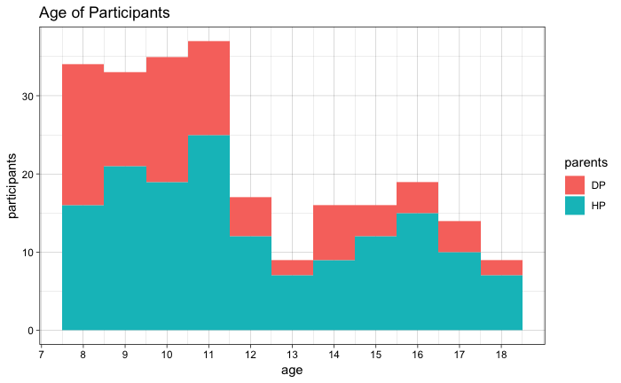

```r
completedata %>%
  ggplot() +
  aes(x = age_at_test, fill = parents) +
  geom_histogram(binwidth = 1) +
  scale_x_continuous(breaks = seq(7,18)) +
  theme_linedraw() +
  labs(x = "age",
       y = "participants",
       title = "Age of Participants")
```

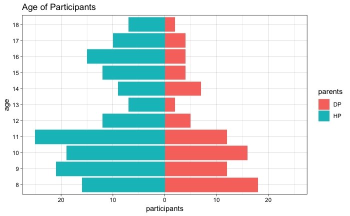

```r
completedata %>%
  ggplot() +
  aes(x = as.factor(age_at_test), fill = parents) +
  geom_bar(data = filter(completedata, parents == "DP")) +
  geom_bar(data = filter(completedata, parents == "HP"),
           mapping = aes(y = - ..count.. ),
           position = "identity") +
  scale_y_continuous(labels = abs, limits = c(-25, 25)) +
  labs(x = "age",
       y = "participants",
       title = "Age of Participants") +
  coord_flip() +
  theme_linedraw()
```

> A model that contains two linear regression for each DP and HP of overall literal accuracy by age with a scatter plot to show individual performance in accordance with two groups (DP and HP)

> A model that shows similar to the first graph but of inferential accuracy.

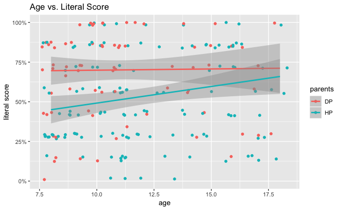

```r
ggplot(completedata) +
  aes(x = age_at_test, y = literal, color = parents) +
  geom_jitter() +
  geom_smooth(method = "lm") +
  scale_y_continuous(labels = scales::percent, limits = c(0,1)) +
  labs(x = "age",
       y = "literal score",
       title = "Age vs. Literal Score")
```

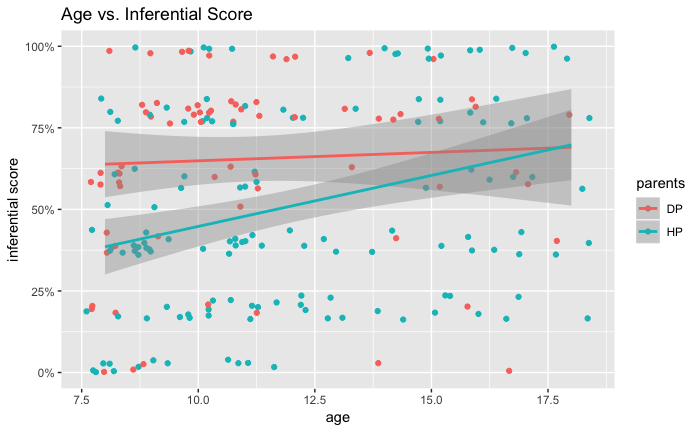

```r
ggplot(completedata) +
  aes(x = age_at_test, y = inferential, color = parents) +
  geom_jitter() +
  geom_smooth(method = "lm") +
  scale_y_continuous(labels = scales::percent, limits = c(0,1)) +
  labs(x = "age",
       y = "inferential score",
       title = "Age vs. Inferential Score")
```

> A model that reveals linear relationships between LC and Vocabulary for each DP and HP with a scatter plot to show individual performance as well.

> Repeat above but between IC and Vocabulary.

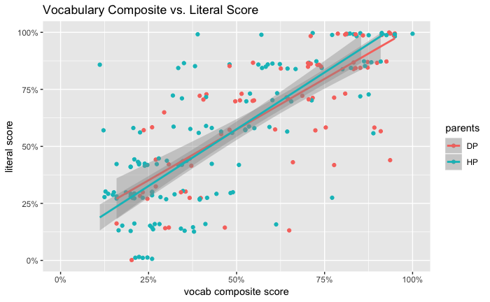

```r
ggplot(completedata) +
  aes(x = vocab_composite, y = literal, color = parents) +
  geom_jitter() +
  geom_smooth(method = "lm") +
  scale_x_continuous(labels = scales::percent, limits = c(0,1)) +
  scale_y_continuous(labels = scales::percent, limits = c(0,1)) +
  labs(x = "vocab composite score",
       y = "literal score",
       title = "Vocabulary Composite vs. Literal Score")
```

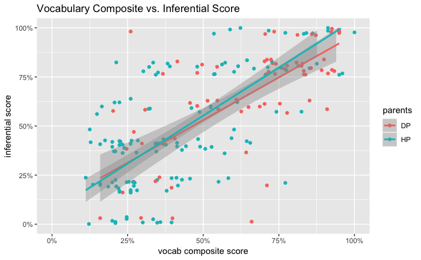

```r
ggplot(completedata) +
  aes(x = vocab_composite, y = inferential, color = parents) +
  geom_jitter() +
  geom_smooth(method = "lm") +
  scale_x_continuous(labels = scales::percent, limits = c(0,1)) +
  scale_y_continuous(labels = scales::percent, limits = c(0,1)) +
  labs(x = "vocab composite score",
       y = "inferential score",
       title = "Vocabulary Composite vs. Inferential Score")
```

> This graph reveals linear relationships between LC and syntax for each DP and HP with a scatter plot to show individual performance.

> Repeat above but between IC and Syntax.

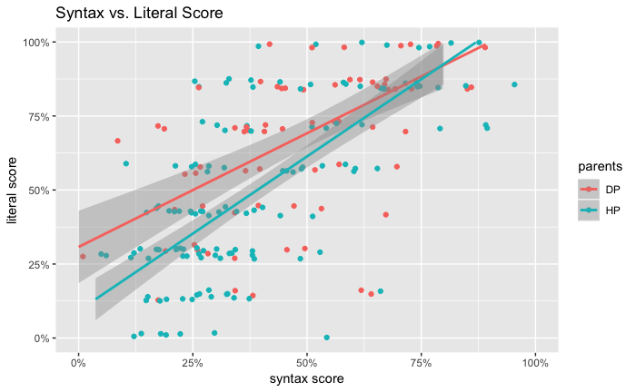

```r
ggplot(completedata) +
  aes(x = stxd4, y = literal, color = parents) +
  geom_jitter() +
  geom_smooth(method = "lm") +
  scale_x_continuous(labels = scales::percent, limits = c(0,1)) +
  scale_y_continuous(labels = scales::percent, limits = c(0,1)) +
  labs(x = "syntax score",
       y = "literal score",
       title = "Syntax vs. Literal Score")
```

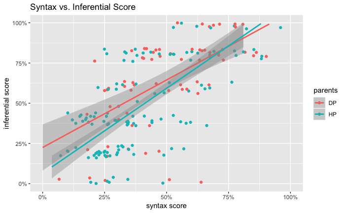

```r
ggplot(completedata) +
  aes(x = stxd4, y = inferential, color = parents) +
  geom_jitter() +
  geom_smooth(method = "lm") +
  scale_x_continuous(labels = scales::percent, limits = c(0,1)) +
  scale_y_continuous(labels = scales::percent, limits = c(0,1)) +
  labs(x = "syntax score",
       y = "inferential score",
       title = "Syntax vs. Inferential Score")
```

> A graph, if can, that shows both LC and IC with RC, otherwise two separate graph for that.

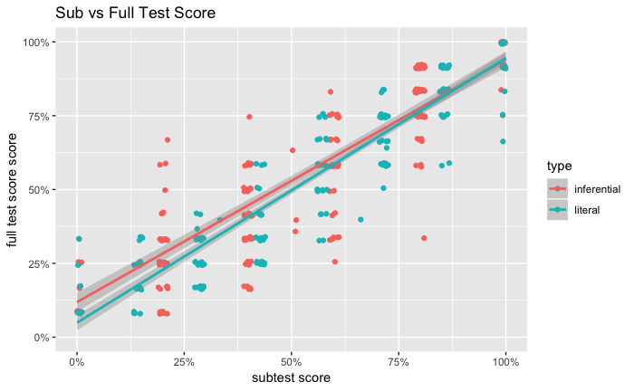

```r
completedata %>%
  select(student_id, inferential, literal, task_percent) %>%
  gather(type, score, inferential:literal) %>%
  ggplot() +
  aes(x = score, y = task_percent, color = type) +
  geom_jitter() +
  geom_smooth(method = "lm") +
  scale_x_continuous(labels = scales::percent, limits = c(0,1)) +
  scale_y_continuous(labels = scales::percent, limits = c(0,1)) +
  labs(x = "subtest score",
       y = "full test score score",
       title = "Sub vs Full Test Score")
```